# DC circuits

In the circuit shown in the figure, $V_A=4.43\,$V. Find $V_{s3}$.

Hint: Write KCL at node A.

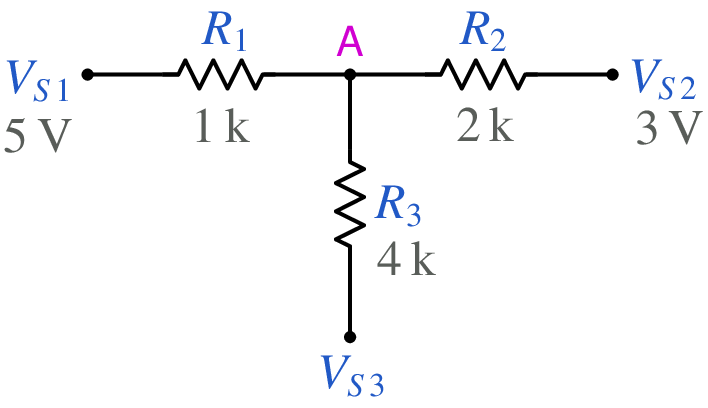

```python
from IPython.display import Image
Image(filename =r'dc_circuit_2_fig_1.png', width=280)
```

```python
# run this cell to view the circuit file.
%pycat dc_circuit_2_orig.in
```

We now replace the string \$Vs3 with the value of our choice by running the python script given below. It takes an existing circuit file `dc_circuit_2_orig.in` and produces a new circuit file `dc_circuit_2.in`, after replacing \$Vs3 with the value of our choice.

```python
import gseim_calc as calc
s_Vs3 = '8' # to be changed by user
l = [
  ('$Vs3', s_Vs3),
]
calc.replace_strings_1("dc_circuit_2_orig.in", "dc_circuit_2.in", l)
print('dc_circuit_2.in is ready for execution')
```

```
dc_circuit_2.in is ready for execution
```

**Execute the following cell to run GSEIM on dc_circuit_2.in.**

```python
import os
import dos_unix
# uncomment for windows:
#dos_unix.d2u("dc_circuit_2.in")
os.system('run_gseim dc_circuit_2.in')
```

```
Circuit: filename = dc_circuit_2.in
GSEIM: Program completed.
```

```
0
```

The circuit file (`dc_circuit_2.in`) is created in the same directory as that used for launching Jupyter notebook. The last step (i.e., running `GSEIM` on `dc_circuit_2.in`) creates the data file `dc_circuit_2.dat` in the same directory. We can now use the python code below to compute and display the quantities of interest.

```python
import numpy as np
import gseim_calc as calc

slv = calc.slv("dc_circuit_2.in")

i_slv = 0
i_out = 0
filename = slv.l_filename_all[i_slv][i_out]
print('filename:', filename)
u = np.loadtxt(filename)
VA = slv.get_scalar_double(i_slv, i_out, "VA", u)
IR1 = slv.get_scalar_double(i_slv, i_out, "IR1", u)
IR2 = slv.get_scalar_double(i_slv, i_out, "IR2", u)
IR3 = slv.get_scalar_double(i_slv, i_out, "IR3", u)

s_format = "%7.2f"
s_format_1 = "%11.4E"

calc.print_double_1('VA', VA, s_format)
calc.print_double_1('IR1', IR1, s_format_1)
calc.print_double_1('IR2', IR2, s_format_1)
calc.print_double_1('IR3', IR3, s_format_1)
```

```
filename: dc_circuit_2.dat
VA:    4.86
IR1:  1.4286E-04
IR2: -9.2857E-04
IR3:  7.8571E-04
```

This notebook was contributed by **Prof. M. B. Patil**, IIT Bombay. He may be contacted at mbpatil@ee.iitb.ac.in.